# UFO Geostatistics

### Fitting Covariance Functions

I fit several different covariance functions to the data. It’s difficult to determine an optimal function in terms of best fit. This is due to the noisyness of the data.

```
## variofit: covariance model used is exponential
## variofit: weights used: cressie
## variofit: minimisation function used: optim
## variofit: searching for best initial value ... selected values:
##               sigmasq phi    tausq  kappa
## initial.value "11.24" "0.09" "2.25" "0.5"
## status        "est"   "est"  "est"  "fix"
## loss value: 458269.61831871
```

```
## variofit: covariance model used is powered.exponential
## variofit: weights used: cressie
## variofit: minimisation function used: optim
## variofit: searching for best initial value ... selected values:
##               sigmasq phi    tausq  kappa
## initial.value "11.24" "0.09" "2.25" "0.5"
## status        "est"   "est"  "est"  "fix"
## loss value: 492071.592850446
```

```
## variofit: covariance model used is matern
## variofit: weights used: cressie
## variofit: minimisation function used: optim
## variofit: searching for best initial value ... selected values:
##               sigmasq phi    tausq  kappa
## initial.value "11.24" "0.09" "5.62" "1"
## status        "est"   "est"  "est"  "fix"
## loss value: 379209.913363904
```

```
## variofit: covariance model used is spherical
## variofit: weights used: cressie
## variofit: minimisation function used: optim
## variofit: searching for best initial value ... selected values:
##               sigmasq phi    tausq  kappa
## initial.value "11.24" "0.09" "2.25" "0.5"
## status        "est"   "est"  "est"  "fix"
## loss value: 653749.454737517
```

```
## variofit: covariance model used is pure.nugget
## variofit: weights used: cressie
```

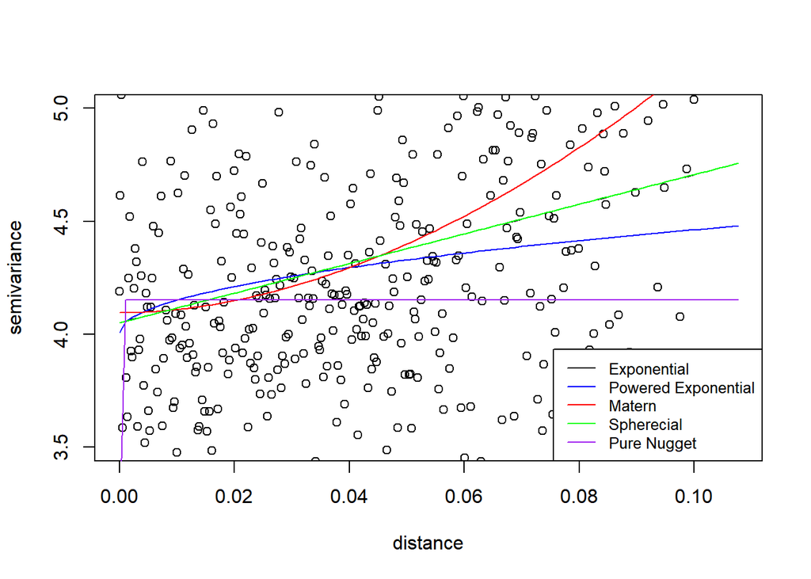

### WLS Prediciton

I arbitrarily choose the sphereical covariance model to estimate model parameters via weighted least squares. Our predictors are longitude and latitude. I display a table of the parameter estimates and the standard errors.

```
## variofit: covariance model used is spherical
## variofit: weights used: cressie
## variofit: minimisation function used: optim
## variofit: searching for best initial value ... selected values:
##               sigmasq phi    tausq  kappa
## initial.value "11.24" "0.09" "2.25" "0.5"
## status        "est"   "est"  "est"  "fix"
## loss value: 653749.454737517
```

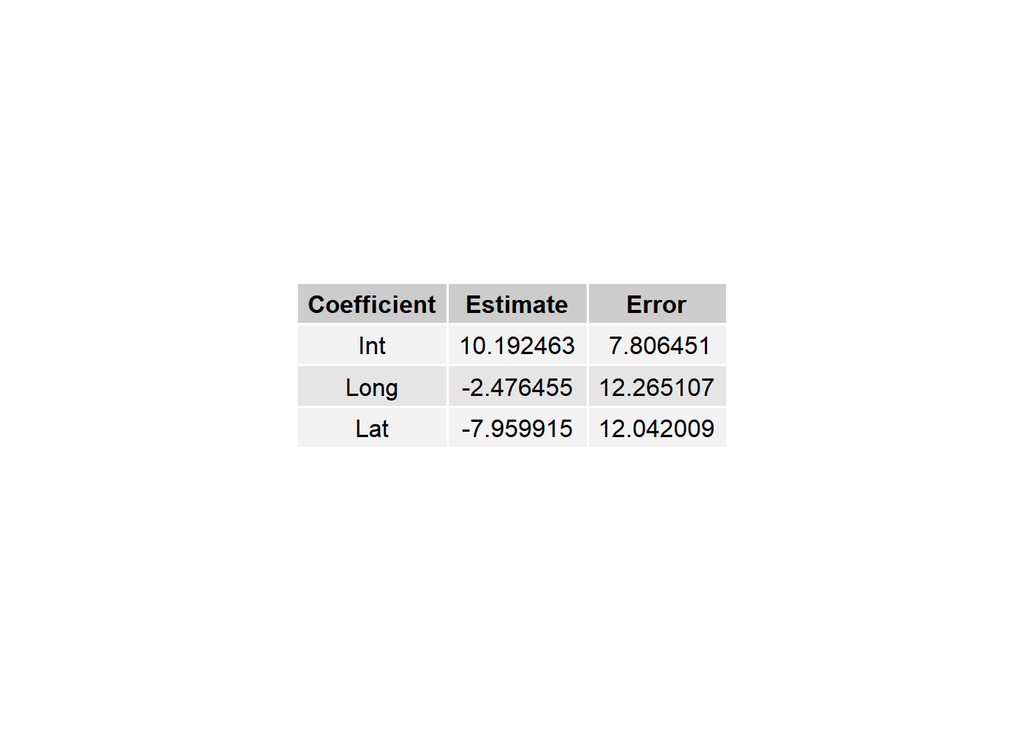

### OLS Prediction

I also compute model parameters using ordinary least squares for comparison. With this model, we assume that there is no spatial correlation in the data. This corresponds to the “pure nugget” covariance model.

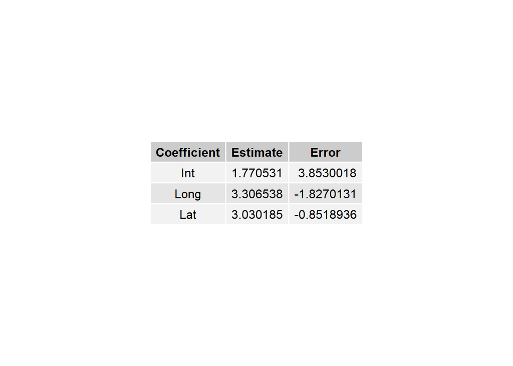

# Summary

We were unable to detect spatial correlation in the dataset. Our evidence comes from examining the data visually, and of course, with the use of semicovariograms.

Overall, I would trust the least squares estimates more than the weighted least squares estimates. For WLS, I believe our main problem occurrs when we estimate parameters for the covariance models. Ultimately, I think these covaraince functions are poor fits to the data. I believe for this dataset, when we assume the presence of a covariance model, we incorporate correlations in the model that are not actually present in the data. This exploads our standard errors and causes a large difference in parameter estimates from the OLS model.